Last time, I examined the relationship between macronutrients and total calories in the data obtained from [menustat.org](http://api.ning.com/files/drL7ji10lw0df0UGzfzR3Wgna8ZmVV2JSf-ebXK3ggx1hTZlYsoH5*nmXIW9-QjqmRicEjoeROQZ4I*FS3FQKPxRpAZuKxwx/100_0218.JPG?width=737&height=552). If you’ll recall, there was something curious about a model I fit. Here it is::

```r
m.1 <- lmer(Calories ~ Proteing + Carbohydratesg + TotalFatg +
       (1+Proteing+Carbohydratesg+TotalFatg|Restaurant), data=df)
summary(m.1)
```

```
## Linear mixed model fit by REML ['lmerMod']
## Formula:
## Calories ~ Proteing + Carbohydratesg + TotalFatg + (1 + Proteing +
##     Carbohydratesg + TotalFatg | Restaurant)
##    Data: df
##
## REML criterion at convergence: 883964
##
## Scaled residuals:
##    Min     1Q Median     3Q    Max
## -40.73  -0.21   0.00   0.21  25.23
##
## Random effects:
##  Groups     Name           Variance Std.Dev. Corr
##  Restaurant (Intercept)    159.0582 12.612
##             Proteing         0.5829  0.763   -0.10
##             Carbohydratesg   0.0875  0.296   -0.53 -0.18
##             TotalFatg        0.4832  0.695   -0.03 -0.81 -0.16
##  Residual                  791.1256 28.127
## Number of obs: 92732, groups: Restaurant, 145
##
## Fixed effects:
##                Estimate Std. Error t value
## (Intercept)      4.5378     1.0789     4.2
## Proteing         4.1855     0.0658    63.6
## Carbohydratesg   3.8220     0.0254   150.4
## TotalFatg        8.9041     0.0598   148.8
##
## Correlation of Fixed Effects:
##             (Intr) Protng Crbhyd
## Proteing    -0.101
## Carbhydrtsg -0.526 -0.178
## TotalFatg   -0.032 -0.800 -0.159
```

Note that the estimates in the model are very close to what we would expect, based on the lawful relationship between each macronutrient and calories:

- **Fats:** 9 kcal/gram
- **Protiens:** 4 kcal/gram
- **Carbohydrates:** 4 kcal/gram

However, it isn’t perfect. In fact, the *way* in which it isn’t perfect made me a little suspicious. Specifically, the estimates all move in the same direction one would expect if there was some kind of social desireability bias at play (i.e. higher than expected protein, lower than expected carbs & fats). To investigate this more closely, I created an index of the random effects which is a measure of how much each restaurant’s nutrition information is biased in socially desireable ways. I refer to the index as ‘reporting tendency’. Negative numbers represent nutrition information which is more socially desireable

```r
rf <- ranef(m.1)
df.rf <- rf$Restaurant
head(df.rf)
```

```
##               (Intercept) Proteing Carbohydratesg TotalFatg
## 7 Eleven          -0.8867 -0.03064       0.138203 -0.074146
## A&W               -0.9206  1.39110      -0.007612 -1.239608
## Applebee's        -6.0821 -0.32459       0.078870  0.211501
## Arby's            -3.1507 -0.26323      -0.040117  0.399497
## Au Bon Pain       -2.4939  0.23709      -0.087233 -0.021850
## Auntie Anne's     -3.6355  0.35671       0.131298  0.003992
```

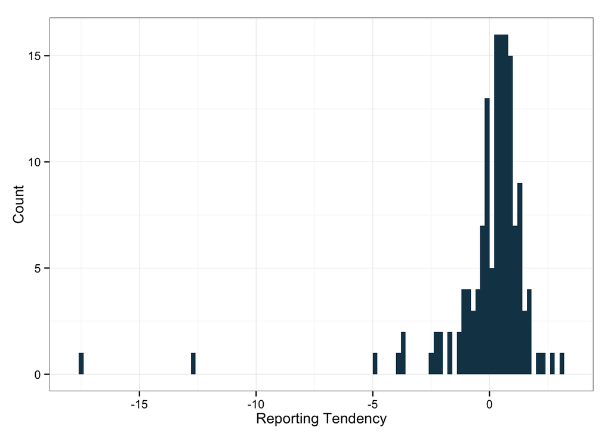

```r
df.rf$Proteing <- scale(df.rf$Proteing)
df.rf$Proteing <- df.rf$Proteing*-1
df.rf$Carbohydratesg <- scale(df.rf$Carbohydratesg)
df.rf$TotalFatg <- scale(df.rf$TotalFatg)

library(ggplot2)
df.rf$reporting.tendency <- df.rf$Proteing + df.rf$Carbohydratesg +
  df.rf$TotalFatg
ggplot(df.rf, aes(x=reporting.tendency)) +
  geom_histogram(binwidth=.2, fill='#144256') +
  theme_bw() + ylab('Count') + xlab('Reporting Tendency')
```

Note that we’ve got a couple of clear outliers. It could be these restaurants which are driving this pattern. Perhaps this is another instance of the data being mis-entered. Let’s dive in and see who these two are.

```r
df.rf[which(df.rf$reporting.tendency < -10), ]
```

```
##                   (Intercept) Proteing Carbohydratesg TotalFatg
## Godfather's Pizza      19.290   -5.046        -5.4341    -2.207
## Round Table Pizza       5.931   -7.940        -0.9182    -8.559
##                   reporting.tendency
## Godfather's Pizza             -12.69
## Round Table Pizza             -17.42
```

Remember that these random effects estimates have all been standardized, so when you see that the estimate for fat is -8.6 as it is for Round Table Pizza, that means that the random effect of total fat for Round Table is 8.6 standard deviations below the mean! Clearly, we should examine the raw data for these two companies. Since they both have quite a large number of items (789 for Godfather, 1266 for Round Table), I’m going to place them into their own dataframe and then look at a scatter of each macronutrient against total calories.

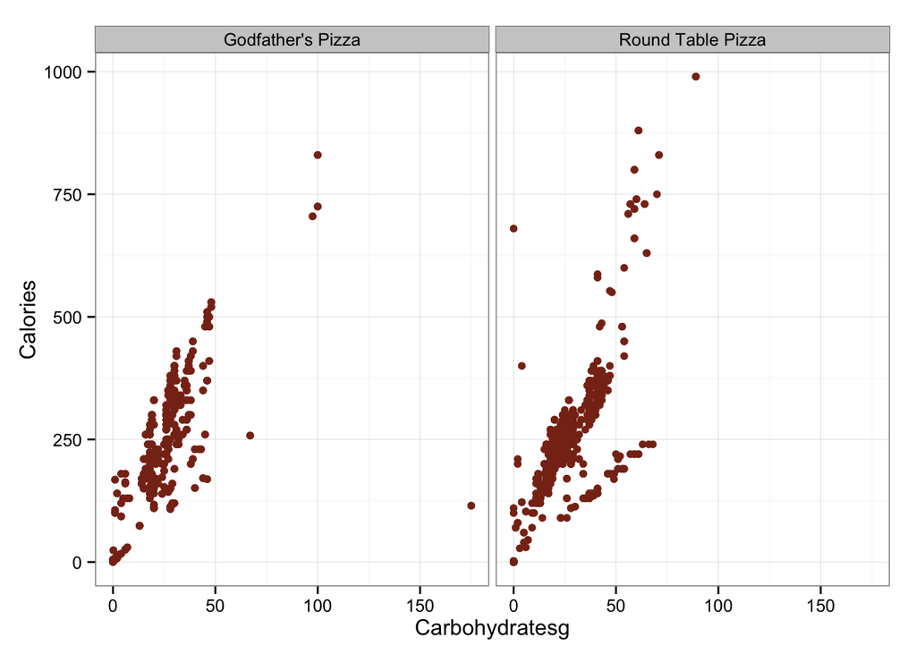

```r
df.pizza <- rbind(df[which(df$Restaurant == "Godfather's Pizza"),],
                      df[which(df$Restaurant == "Round Table Pizza"),])
ggplot(df.pizza, aes(x=Carbohydratesg, y=Calories)) +
  geom_point(color='#88301B') + facet_wrap(~Restaurant) +
  theme_bw()
```

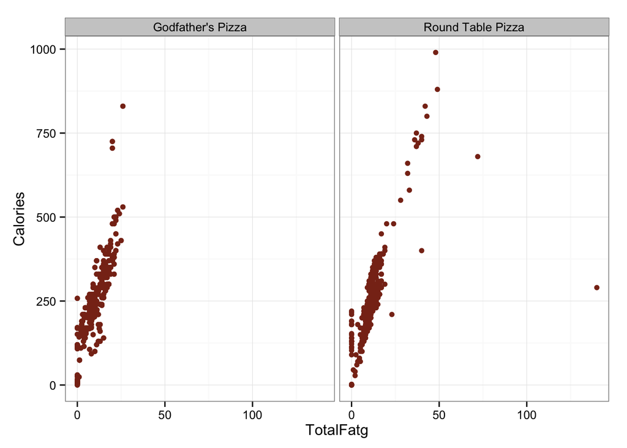

```r
ggplot(df.pizza, aes(x=TotalFatg, y=Calories)) +
  geom_point(color='#88301B') + facet_wrap(~Restaurant) +
  theme_bw()
```

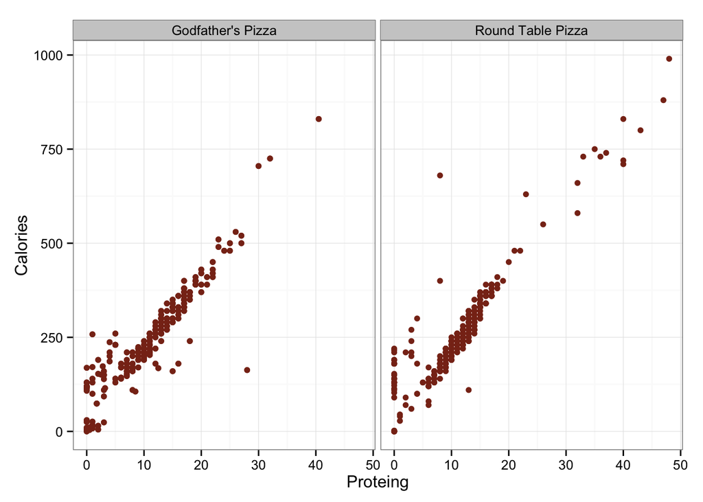

```r
ggplot(df.pizza, aes(x=Proteing, y=Calories)) +
  geom_point(color='#88301B') + facet_wrap(~Restaurant) +
  theme_bw()
```

This doesn’t look like anything too fishy. I’m guessing that the huge effect of carbs in Godfather’s is being driven by the outlier way out ~175 carbs and 125 calories. Ditto for Round Table being driven by the outlier out near 150 grams of fat. Interestingly, the plot for carbohydrates seems to have two distinct groups in both chains, but it is esspecially pronounced for Round Table. Note all the data points clustered together in a line that is below the larger cluster. It looks like if we define a line that runs through the origin and the point (x=50, y=250), we can just grab the values which are below that for a sense of what these items are. Let’s give that a shot.

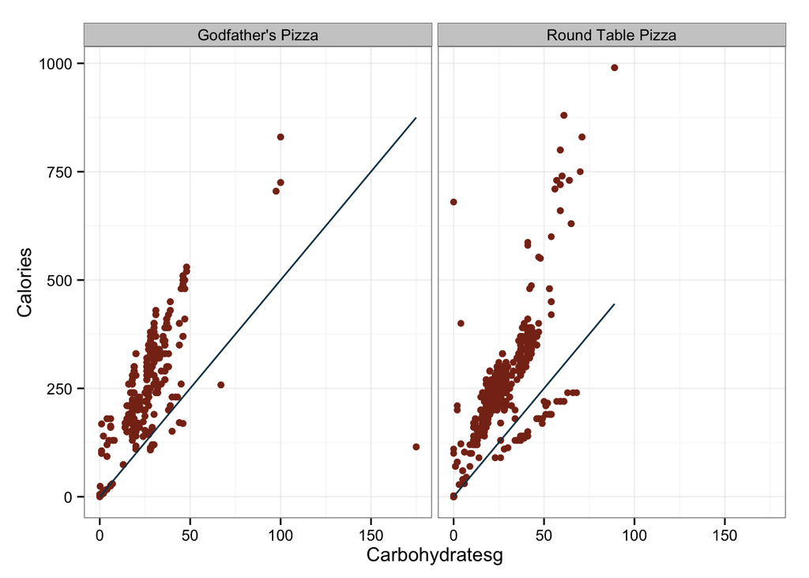

```r
df.pizza$line <- 5*df.pizza$Carbohydratesg
ggplot(df.pizza, aes(x=Carbohydratesg, y=Calories)) +
  geom_point(color='#88301B') + facet_wrap(~Restaurant) +
  geom_line(aes(x=Carbohydratesg, y=line), color='#144256')+
  theme_bw()
```

That looks okay. Let’s get everything smaller than the values in that line.

```r
df.pizza[sample(which(df.pizza$Calories < df.pizza$line), 20),c(1, 3, 11, 12, 18, 21)]
```

```
##               Restaurant                     Item_Name. Calories TotalFatg
## 69335  Godfather's Pizza                   Classic Coke      117         0
## 133306 Round Table Pizza                   Pepsi, Small      130         0
## 69595  Godfather's Pizza                          Pears      258         0
## 132728 Round Table Pizza              Dr Pepper, Medium      135        NA
## 69415  Godfather's Pizza               Fat Free Italian       30         0
## 133520 Round Table Pizza   Tropicana Fruit Punch, Small      140        NA
## 133232 Round Table Pizza           Mug Root Beer, Large      220        NA
## 133318 Round Table Pizza               Polynesian Sauce      220         0
## 133525 Round Table Pizza     Tropicana Lemonade, Medium      180         0
## 132731 Round Table Pizza               Dr Pepper, Small       90        NA
## 132709 Round Table Pizza          Diet Dr Pepper, Small      113         0
## 132721 Round Table Pizza              Dole Orange Juice      210         0
## 69656  Godfather's Pizza              Pineapple Tidbits      108         0
## 69301  Godfather's Pizza                    Cherry Coke      120         0
```

[output cut: 27 more lines]

Ah. Basically, this is soda, which is typically made up of nothing but carbohydrates.

Okay, let’s remove the two crazy outliers and see about refitting the model.

```r
library(dplyr)
df %>%
  filter(TotalFatg>125) %>%
  filter(Restaurant == "Round Table Pizza")
```

```
##          Restaurant Food.Category.
## 1 Round Table Pizza          Pizza
##                                  Item_Name. Menu_Item_ID year
## 1 Smokehouse Combo on Original Crust, Large        72354 2014
##                             ItemDescription ServingsPerItem ServingSize
## 1 Smokehouse Combo on Original Crust, Large              12         117
##   ServingSizeUnit ServingsSizeText Calories TotalFatg SaturatedFatg
## 1            <NA>          1 Slice      290       140             6
##   TransFatg Cholesterolmg Sodiummg Potassiummg Carbohydratesg Fiberg
## 1         0            40      720        <NA>             26      2
##   Sugarg Proteing
## 1      3       13
```

```r
df %>%
  filter(Carbohydratesg>150) %>%
  filter(Restaurant == "Godfather's Pizza")
```

```
##          Restaurant Food.Category.            Item_Name. Menu_Item_ID year
## 1 Godfather's Pizza    Baked Goods Monkey Bread, Italian        43760 2014
## 2 Godfather's Pizza    Baked Goods Monkey Bread, Italian        43760 2013
##                        ItemDescription ServingsPerItem ServingSize
## 1 Monkey Bread, Italian, 9 in Foil Pan               6          42
## 2 Monkey Bread, Italian, 9 in Foil Pan               6          42
##   ServingSizeUnit ServingsSizeText Calories TotalFatg SaturatedFatg
## 1            <NA>         1/6 Dish      115       3.8          0.75
## 2            <NA>          1 Slice      115       3.8          0.75
##   TransFatg Cholesterolmg Sodiummg Potassiummg Carbohydratesg Fiberg
## 1         0             0      162        <NA>            175    0.8
## 2         0             0      162        <NA>            175    0.8
##   Sugarg Proteing
## 1   0.83      3.2
## 2   0.83      3.2
```

Okay, items 72354 and 43760. We can remove those without too much difficulty. Let’s just double check that we wont do too much damage by removing all carb and fat entires with those values.

```r
df[which(df$Menu_Item_ID == 43760),]
```

```
##              Restaurant Food.Category.            Item_Name. Menu_Item_ID
## 69574 Godfather's Pizza    Baked Goods Monkey Bread, Italian        43760
## 69575 Godfather's Pizza    Baked Goods Monkey Bread, Italian        43760
## 69576 Godfather's Pizza    Baked Goods Monkey Bread, Italian        43760
##       year                      ItemDescription ServingsPerItem
## 69574 2014 Monkey Bread, Italian, 9 in Foil Pan               6
## 69575 2013 Monkey Bread, Italian, 9 in Foil Pan               6
## 69576 2012                                                 <NA>
##       ServingSize ServingSizeUnit ServingsSizeText Calories TotalFatg
## 69574          42            <NA>         1/6 Dish      115       3.8
## 69575          42            <NA>          1 Slice      115       3.8
## 69576        <NA>            <NA>                        NA        NA
##       SaturatedFatg TransFatg Cholesterolmg Sodiummg Potassiummg
## 69574          0.75         0             0      162        <NA>
## 69575          0.75         0             0      162        <NA>
## 69576          <NA>      <NA>          <NA>     <NA>        <NA>
##       Carbohydratesg Fiberg Sugarg Proteing
## 69574            175    0.8   0.83      3.2
## 69575            175    0.8   0.83      3.2
## 69576             NA   <NA>   <NA>       NA
```

```r
df[which(df$Menu_Item_ID == 72354),]
```

```
##               Restaurant Food.Category.
## 133381 Round Table Pizza          Pizza
## 133382 Round Table Pizza          Pizza
## 133383 Round Table Pizza          Pizza
##                                       Item_Name. Menu_Item_ID year
## 133381 Smokehouse Combo on Original Crust, Large        72354 2014
## 133382 Smokehouse Combo on Original Crust, Large        72354 2013
## 133383 Smokehouse Combo on Original Crust, Large        72354 2012
##                                  ItemDescription ServingsPerItem
## 133381 Smokehouse Combo on Original Crust, Large              12
## 133382                                                      <NA>
## 133383                                                      <NA>
##        ServingSize ServingSizeUnit ServingsSizeText Calories TotalFatg
## 133381         117            <NA>          1 Slice      290       140
## 133382        <NA>            <NA>                        NA        NA
## 133383        <NA>            <NA>                        NA        NA
##        SaturatedFatg TransFatg Cholesterolmg Sodiummg Potassiummg
## 133381             6         0            40      720        <NA>
## 133382          <NA>      <NA>          <NA>     <NA>        <NA>
## 133383          <NA>      <NA>          <NA>     <NA>        <NA>
##        Carbohydratesg Fiberg Sugarg Proteing
## 133381             26      2      3       13
## 133382             NA   <NA>   <NA>       NA
## 133383             NA   <NA>   <NA>       NA
```

```r
df$Carbohydratesg[which(df$Menu_Item_ID == 43760)] <- NA
df$TotalFatg[which(df$Menu_Item_ID == 72354)] <- NA
m.2 <- lmer(Calories ~ Proteing + Carbohydratesg + TotalFatg +
       (1+Proteing+Carbohydratesg+TotalFatg|Restaurant), data=df)
summary(m.2)
```

```
## Linear mixed model fit by REML ['lmerMod']
## Formula:
## Calories ~ Proteing + Carbohydratesg + TotalFatg + (1 + Proteing +
##     Carbohydratesg + TotalFatg | Restaurant)
##    Data: df
##
## REML criterion at convergence: 882757
##
## Scaled residuals:
##    Min     1Q Median     3Q    Max
## -40.96  -0.21   0.00   0.21  25.37
##
## Random effects:
##  Groups     Name           Variance Std.Dev. Corr
##  Restaurant (Intercept)    154.3963 12.426
##             Proteing         0.2203  0.469   -0.31
##             Carbohydratesg   0.0685  0.262   -0.53  0.14
##             TotalFatg        0.2135  0.462    0.06 -0.63 -0.52
##  Residual                  782.7674 27.978
## Number of obs: 92729, groups: Restaurant, 145
##
## Fixed effects:
##                Estimate Std. Error t value
## (Intercept)      4.3421     1.0629     4.1
## Proteing         4.1200     0.0421    97.9
## Carbohydratesg   3.8364     0.0226   169.8
## TotalFatg        8.9555     0.0409   218.7
##
## Correlation of Fixed Effects:
##             (Intr) Protng Crbhyd
## Proteing    -0.290
## Carbhydrtsg -0.523  0.109
## TotalFatg    0.044 -0.628 -0.491
```

Looks a bit better. I guess I was making a mountain out of a mole hill. We could continue to play the remove-the-outlier game all day, I’m sure, but I’m not really interested in doing it.